# Activity monitoring

Jeff Kian

Thursday, May 14, 2015

### Load and Process the data

##### Load the data

Steps taken:  
1. Set the working directory  
2. Initialise the relevant libraries e.g (dplyr)  
3. Read the data set into the actvity data

```r
setwd("C:/Users/jeffk_000/Dropbox/Work Files/BI/Information Management/07. Data Scientist Toolbox/05. Reproducible Research/Assignment 1/repdata-data-activity")
library(dplyr)
library(sqldf)
```

```r
library(data.table)
library(ggplot2)
ActData<-read.csv("activity.csv")
```

##### Process the data

Approach

1. For each day calculate the total number of steps for that day
2. Use the group function from dplyr to group the data and assign to Aggregate Activity data table (AggActData)
3. Use the summarise function to summarise steps by date and don’t consider NA records
4. Add a weekday indicator onto this summary table

```r
AggActData<-ActData %>%
group_by(date) %>%
summarise(TotalSteps=sum(steps,na.rm=TRUE))
AggActData$day <- weekdays(as.Date(AggActData$date))
```

#### Question 1: What is mean total number of steps taken per day?

1. Calculate the total nuber of steps per day
2. Create a Histogram of total number of steps

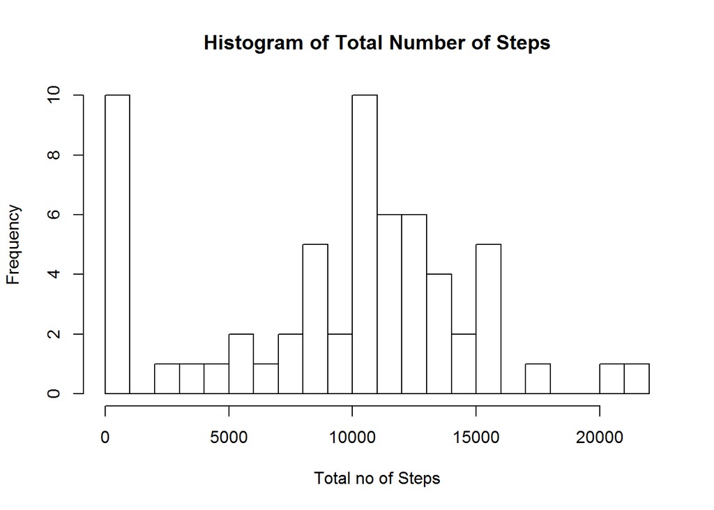

```r
hist(AggActData$TotalSteps,
     breaks=20,
     xlab="Total no of Steps",
     main="Histogram of Total Number of Steps")
```

The median of the Total Steps for all days is

```r
median(AggActData$TotalSteps)
```

```
## [1] 10395
```

The mean of the total steps for all days is

```r
mean(AggActData$TotalSteps)
```

```
## [1] 9354.23
```

#### Question 2: What is the average daily activity pattern?

Q 2.1 Make a time series plot (i.e. type = “l”) of the 5-minute interval (x-axis) and the average number of steps taken, averaged across all days (y-axis)

Approach

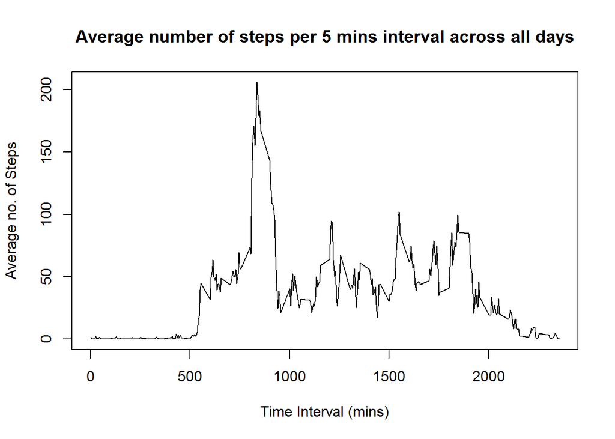

```r
AggActData2<-ActData %>%
group_by(interval) %>%
summarise(AveSteps=mean(steps,na.rm=TRUE))

plot(AggActData2$interval, AggActData2$AveSteps,type="l", xlab="Time Interval (mins)",ylab="Average no. of Steps",main="Average number of steps per 5 mins interval across all days")
```

Q 2.2 Show which 5 mins interval i.e. which time of day has the most steps

Approach

- Identify which time interval has the highest number of steps.
- Find the index of the row number where the number of steps is the maximum number of steps
- Use that row number to identify the interval

```r
AggActData2[which(AggActData2$AveSteps==max(AggActData2$AveSteps)),1]
```

```
## Source: local data frame [1 x 1]
##
##   interval
## 1      835
```

#### Question 3: Inputting Missing Values

3.1 Calculate and report the total number of missing values in the dataset (i.e. the total number of rows with NAs)

Approach

- Firstly identify which records is.na return true the code will generate a vector with logical values indicating if the rows have an NA value
- Use the which function to identify the row numbers
- Use the length function to count the number of entries in the NA vector, this will indicate the number of records with NA values

The total number of observations that have NA values is:

```r
length(which(is.na(ActData$steps)=="TRUE"))
```

```
## [1] 2304
```

3.2 Create a new dataset that has the missing values filled in

Approach  
- Using the sqldf library join the Activity data (Steps by interval by day ActData)to the previously calculated Average Steps per interval (AggActData2 that excluded NA)  
- Using the mutate function from dplyr create a new column AveStepsFixed  
- Embed conditional statement that evaluates whether the steps in the original activity data for that interval were empty  
- If they were NA replace with the calculated Average steps for that interval Else use the existing steps for that interval

```r
ActData2<-sqldf('select ActData.steps,ActData.date,ActData.interval,AggActData2.AveSteps from ActData join AggActData2 using (interval) ')
ActDataFixed<-mutate(ActData2,AveStepsFixed=ifelse(is.na(ActData2$steps)==TRUE,AveSteps,steps))
head(ActDataFixed)
```

```
##   steps       date interval  AveSteps AveStepsFixed
## 1    NA 2012-10-01        0 1.7169811     1.7169811
## 2    NA 2012-10-01        5 0.3396226     0.3396226
## 3    NA 2012-10-01       10 0.1320755     0.1320755
## 4    NA 2012-10-01       15 0.1509434     0.1509434
## 5    NA 2012-10-01       20 0.0754717     0.0754717
## 6    NA 2012-10-01       25 2.0943396     2.0943396
```

3.3 Make a histogram of the total number of steps taken each day

```r
AggActDataFixed<-ActDataFixed %>%
group_by(date) %>%
summarise(TotalSteps=sum(AveStepsFixed,na.rm=TRUE))
AggActDataFixed$day <- weekdays(as.Date(AggActDataFixed$date))
```

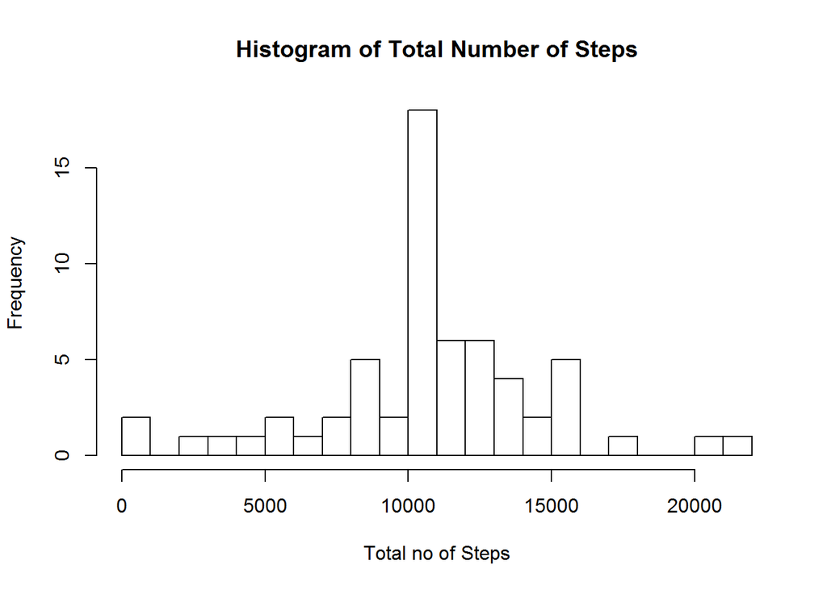

```r
hist(AggActDataFixed$TotalSteps,
     breaks=20,
     xlab="Total no of Steps",
     main="Histogram of Total Number of Steps")
```

3.4 Calculate and report the mean and median total number of steps taken per day based on the fixed data

The median of the Total Steps for all days is

```r
median(AggActDataFixed$TotalSteps)
```

```
## [1] 10766.19
```

The mean of the total steps for all days is

```r
mean(AggActDataFixed$TotalSteps)
```

```
## [1] 10766.19
```

#### Q4. Are there differences in activity patterns between weekdays and weekends?

Approach

```r
ActDataFixed$dayofweek <- wday(as.Date(ActDataFixed$date))
ActDataFixed<-mutate(ActDataFixed,WeekEndInd=ifelse(ActDataFixed$dayofweek ==1 | ActDataFixed$dayofweek ==7,"Weekend","Weekday"))
head(ActDataFixed,15)
```

```
##    steps       date interval  AveSteps AveStepsFixed dayofweek WeekEndInd
## 1     NA 2012-10-01        0 1.7169811     1.7169811         2    Weekday
## 2     NA 2012-10-01        5 0.3396226     0.3396226         2    Weekday
## 3     NA 2012-10-01       10 0.1320755     0.1320755         2    Weekday
## 4     NA 2012-10-01       15 0.1509434     0.1509434         2    Weekday
## 5     NA 2012-10-01       20 0.0754717     0.0754717         2    Weekday
## 6     NA 2012-10-01       25 2.0943396     2.0943396         2    Weekday
## 7     NA 2012-10-01       30 0.5283019     0.5283019         2    Weekday
## 8     NA 2012-10-01       35 0.8679245     0.8679245         2    Weekday
## 9     NA 2012-10-01       40 0.0000000     0.0000000         2    Weekday
## 10    NA 2012-10-01       45 1.4716981     1.4716981         2    Weekday
## 11    NA 2012-10-01       50 0.3018868     0.3018868         2    Weekday
## 12    NA 2012-10-01       55 0.1320755     0.1320755         2    Weekday
## 13    NA 2012-10-01      100 0.3207547     0.3207547         2    Weekday
## 14    NA 2012-10-01      105 0.6792453     0.6792453         2    Weekday
## 15    NA 2012-10-01      110 0.1509434     0.1509434         2    Weekday
```

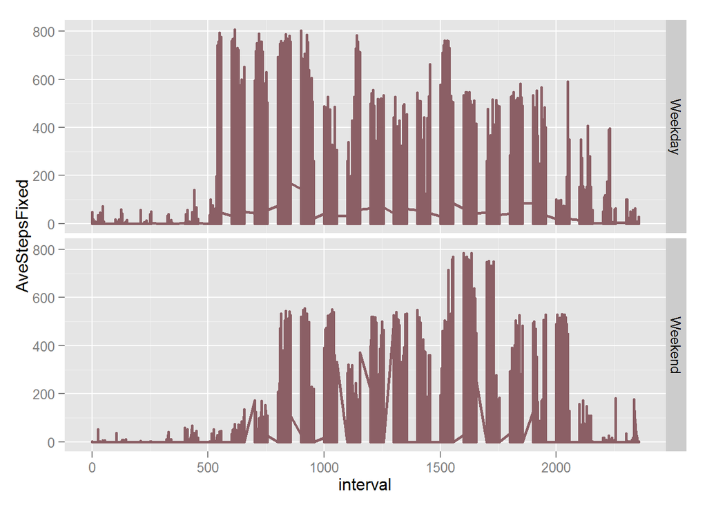

```r
ggplot(ActDataFixed, aes(interval,AveStepsFixed))+geom_line(color="lightpink4", lwd=1)+facet_grid(WeekEndInd ~ .)
```

### Observations

Weekdays are charaterised by more activity (steps) during the early portions of the day. This may possibly be attributed to people walking to get to work or to their means of transport to get to work. Weekday activity remains fairly constant during the middle and latter portions with slight spike potentially during lunch periods and tapering off toward the evening. Interesting is that there is not the same actvity as early in the monring when people go to work in the evening when you would expect them to walk home.